# Procesamiento de la Encuesta Nacional a Grandes Empresas

# Unificacion de unidades

```r
df_enge = base.ENGE_1993a2022.bind
head(df_enge)
```

| id | anio | indicador | unidad | sector | valor |
| --- | --- | --- | --- | --- | --- |
| 1 | 1993 | act.corriente.sobre.act.total | porciento | total | NA |
| 1 | 1993 | act.corriente.sobre.act.total | porciento | minas | NA |
| 1 | 1993 | act.corriente.sobre.act.total | porciento | manufactura.subtotal | NA |
| 1 | 1993 | act.corriente.sobre.act.total | porciento | manufactura.alimentos | NA |
| 1 | 1993 | act.corriente.sobre.act.total | porciento | manufactura.combustibles | NA |
| 1 | 1993 | act.corriente.sobre.act.total | porciento | manufactura.maquinaria | NA |

```r
prop_missing <- apply(is.na(df_enge), 2, function(x) sum(x) / nrow(df_enge))
prop_missing
```

```
       id      anio indicador    unidad    sector     valor
0.0000000 0.0000000 0.0000000 0.0000000 0.0000000 0.5307507
```

```r
# df_enge <-  df_enge%>%
#   filter(!is.na(valor))
table(df_enge$unidad)
```

```
      cantidad    coeficiente          pesos    pesos.miles pesos.millones      porciento
          2100           3175           1175            300          13925           6300
```

## Indicadores en pesos

```r
df_homogeneo <- df_enge %>%
  rbind(df_enge %>%
          filter(unidad == "pesos.millones") %>%
          mutate(valor = valor * 1e6,
                 unidad = 'pesos')
        ) %>%
  rbind(df_enge %>%
          filter(unidad == "pesos.miles") %>%
          mutate(valor = valor * 1e3,
                 unidad = 'pesos')
        ) %>%
  filter(  !(unidad  %in% c("pesos.millones", "pesos.miles")) )

print(table(df_homogeneo$unidad))
```

```
   cantidad coeficiente       pesos   porciento
       2100        3175       15400        6300
```

```r
print('cantidad de filas iguales?')
```

```
[1] "cantidad de filas iguales?"
```

```r
print(nrow (df_homogeneo) == nrow (df_enge))
```

```
[1] TRUE
```

```r
tail (df_homogeneo)
```

| id | anio | indicador | unidad | sector | valor |
| --- | --- | --- | --- | --- | --- |
| 1 | 2004 | VAB.por.ocupado | pesos | manufactura.minerales | NA |
| 1 | 2004 | VAB.por.ocupado | pesos | manufactura.nocat | NA |
| 1 | 2004 | VAB.por.ocupado | pesos | otras.construccion | NA |
| 1 | 2004 | VAB.por.ocupado | pesos | otras.comercio | NA |
| 1 | 2004 | VAB.por.ocupado | pesos | otras.transporte.almacenamiento | NA |
| 1 | 2004 | VAB.por.ocupado | pesos | otras.nocat | NA |

```r
df_pesos <- df_homogeneo %>% filter(unidad %in% c("pesos"))

# Get unique values of "indicador"
unique_indicadores_pesos <- unique(df_pesos$indicador)
unique_indicadores_pesos
```

```
 [1] "salario.medio"                   "utilidad.por.ocupado"
 [3] "VAB.por.ocupado"                 "activo"
 [5] "expo"                            "IBF"
 [7] "impo"                            "patrimonio.neto"
 [9] "salarios"                        "saldo.comercial.bienes"
[11] "utilidad"                        "VAB"
[13] "VBP"                             "amortizaciones"
[15] "c.intermedio"                    "contribuciones"
[17] "impuesto.prod"                   "indemnizaciones"
[19] "interes.rentas.cob"              "interes.rentas.pag"
[21] "subsidios"                       "VAN"
[23] "acreedor_o_deudor_neto"          "adquisiciones.netas"
[25] "ahorro_bruto"                    "FBK_edificios_subtotal"
[27] "FBK_maq.equip_infor.telec"       "FBK_maq.equip_otros"
[29] "FBK_maq.equip_subtotal"          "FBK_maq.equip_transport"
[31] "FBK_prop.intelect_espar"         "FBK_prop.intelect_explor.minera"
[33] "FBK_prop.intelect_informat"      "FBK_prop.intelect_otros"
[35] "FBK_prop.intelect_subtotal"      "FBK_total"
[37] "FBK_var.stock"                   "impuestos.prod"
[39] "result.oper"
```

```r
# Group by 'anio' and count the number of unique 'indicador' values in each group
df_grouped <- df_pesos %>%
  group_by(anio) %>%
  summarise(count = n_distinct(indicador)) %>%
  arrange(count)
print(df_grouped)
```

| anio | count |
| --- | --- |
| 1993 | 12 |
| 1994 | 12 |
| 1995 | 12 |
| 1996 | 12 |
| 1997 | 12 |
| 1998 | 12 |
| 1999 | 12 |
| 2000 | 12 |
| 2001 | 12 |
| 2002 | 12 |

[output cut: 21 more lines]

### Indicadores que faltan por año

```r
# Assuming your dataframes are called 'df_homogeneo' and 'df_pesos' (as defined earlier)

# Efficiently compare unique indicators with indicators in each year
missing_indicators_by_year <- function(unique_indicators, df_grouped) {
  missing_indicators <- sapply(df_grouped$anio, function(year) {
    # Filter indicators for the current year
    year_indicators <- df_homogeneo %>%
      filter(anio == year & unidad %in% c("pesos")) %>%
      pull(indicador)  # Extract only 'indicador' values

    # Find missing indicators in the current year
    missing <- setdiff(unique_indicators, year_indicators)
    return(paste(missing, collapse = ", "))  # Combine missing indicators with comma
  })

  # Combine missing indicators from all years into a data frame
  missing_indicators_df <- data.frame(anio = df_grouped$anio, missing_variables = missing_indicators)
  return(missing_indicators_df)
}

# Get the missing indicators by year
missing_indicators_by_year <- missing_indicators_by_year(unique_indicadores_pesos, df_grouped)

# Print the missing indicators by year (desired format)
print(missing_indicators_by_year)
```

| anio | missing_variables |
| --- | --- |
| 1993 | utilidad.por.ocupado, amortizaciones, c.intermedio, contribuciones, impuesto.prod, indemnizaciones, interes.rentas.cob, interes.rentas.pag, subsidios, VAN, acreedor_o_deudor_neto, adquisiciones.netas,… |
| 1994 | utilidad.por.ocupado, amortizaciones, c.intermedio, contribuciones, impuesto.prod, indemnizaciones, interes.rentas.cob, interes.rentas.pag, subsidios, VAN, acreedor_o_deudor_neto, adquisiciones.netas,… |
| 1995 | utilidad.por.ocupado, amortizaciones, c.intermedio, contribuciones, impuesto.prod, indemnizaciones, interes.rentas.cob, interes.rentas.pag, subsidios, VAN, acreedor_o_deudor_neto, adquisiciones.netas,… |
| 1996 | utilidad.por.ocupado, amortizaciones, c.intermedio, contribuciones, impuesto.prod, indemnizaciones, interes.rentas.cob, interes.rentas.pag, subsidios, VAN, acreedor_o_deudor_neto, adquisiciones.netas,… |
| 1997 | utilidad.por.ocupado, amortizaciones, c.intermedio, contribuciones, impuesto.prod, indemnizaciones, interes.rentas.cob, interes.rentas.pag, subsidios, VAN, acreedor_o_deudor_neto, adquisiciones.netas,… |
| 1998 | utilidad.por.ocupado, amortizaciones, c.intermedio, contribuciones, impuesto.prod, indemnizaciones, interes.rentas.cob, interes.rentas.pag, subsidios, VAN, acreedor_o_deudor_neto, adquisiciones.netas,… |
| 1999 | utilidad.por.ocupado, amortizaciones, c.intermedio, contribuciones, impuesto.prod, indemnizaciones, interes.rentas.cob, interes.rentas.pag, subsidios, VAN, acreedor_o_deudor_neto, adquisiciones.netas,… |
| 2000 | utilidad.por.ocupado, amortizaciones, c.intermedio, contribuciones, impuesto.prod, indemnizaciones, interes.rentas.cob, interes.rentas.pag, subsidios, VAN, acreedor_o_deudor_neto, adquisiciones.netas,… |
| 2001 | utilidad.por.ocupado, amortizaciones, c.intermedio, contribuciones, impuesto.prod, indemnizaciones, interes.rentas.cob, interes.rentas.pag, subsidios, VAN, acreedor_o_deudor_neto, adquisiciones.netas,… |
| 2002 | utilidad.por.ocupado, amortizaciones, c.intermedio, contribuciones, impuesto.prod, indemnizaciones, interes.rentas.cob, interes.rentas.pag, subsidios, VAN, acreedor_o_deudor_neto, adquisiciones.netas,… |

[output cut: 21 more lines]

```r
NA
```

## Indicadores con unidad en porciento y coeficiente

```r
see_unique_unidades <- function(df, unidades){

  df_filtered <- df %>% filter(unidad %in% unidades)

  # Get unique values of "indicador"
  unique_indicadores <- unique(df_filtered$indicador)
  unique_indicadores
}
cat('coeficiente\n')
```

```
coeficiente
```

```r
see_unique_unidades(df_enge, 'coeficiente')
```

```
[1] "coef.VAB"             "deuda.sobre.activo"   "deuda.sobre.k.propio"
[4] "liq.corriente"        "apalancamiento"       "autofinanciamiento"
[7] "deuda.pasivo"
```

```r
cat('\nporciento\n')
```

```
porciento
```

```r
see_unique_unidades(df_enge, 'porciento')
```

```
 [1] "act.corriente.sobre.act.total"            "amortizaciones.en.VAB"
 [3] "contribuciones.sobre.costo.salarial"      "costo.salarial.en.VAB"
 [5] "impuestos.net.subsidios.en.VAB"           "rentabilidad.sobre.act"
 [7] "rentabilidad.sobre.k.propio"              "result.oper.en.VAB"
 [9] "tasa.inversion"                           "salarios.en.VAB"
[11] "VAB.por.ocupado"                          "utilidad.en.VAB"
[13] "utilidad.por.ocupado.sobre.salario.medio"
```

### Indicadores con sobre

```r
filtered_indices <- which(grepl(".sobre.", df_enge$indicador))

# Filter the dataframe using the indices
df_filtered <- df_enge[filtered_indices, ]
unique(df_filtered$indicador)
```

```
[1] "act.corriente.sobre.act.total"            "contribuciones.sobre.costo.salarial"
[3] "deuda.sobre.activo"                       "deuda.sobre.k.propio"
[5] "rentabilidad.sobre.act"                   "rentabilidad.sobre.k.propio"
[7] "utilidad.por.ocupado.sobre.salario.medio"
```

```r
df_enge %>%
  filter(str_detect(indicador, "\\.sobre")) %>%
  count(unidad, indicador)
```

| unidad | indicador | n |
| --- | --- | --- |
| coeficiente | deuda.sobre.activo | 575 |
| coeficiente | deuda.sobre.k.propio | 575 |
| porciento | act.corriente.sobre.act.total | 575 |
| porciento | contribuciones.sobre.costo.salarial | 625 |
| porciento | rentabilidad.sobre.act | 575 |
| porciento | rentabilidad.sobre.k.propio | 575 |
| porciento | utilidad.por.ocupado.sobre.salario.medio | 275 |

# Elaboración de indicadores

```r
#Reestructuro la base pivoteando los indicadores en columnas como variable separadas
# base.ENGE_1993a2022.wider <- base.ENGE_1993a2022.bind %>%
#   pivot_wider(names_from  = c(indicador,unidad),
#               names_sep = "_",
#               values_from = valor)

#problema de que me convirtió los vectores en listas

#Buscar alguna manera de reemplazar los NULL por NA
```

```r
df_pivot <- df_homogeneo %>%
  filter(unidad %in% c("pesos", "cantidad","porciento","coeficiente") | indicador %in% c(
    "salarios.en.VAB", "impuestos.net.subsidios.en.VAB",
    "act.corriente.sobre.act.total", "amortizaciones.en.VAB","costo.salarial.en.VAB","
result.oper.en.VAB"
  )) %>%
  select(-unidad) %>%
   group_by(anio, sector, indicador) %>%
  # mutate(id=row_number())
  summarise(valor = sum(valor, na.rm = TRUE)) %>%
  ungroup() %>%
  pivot_wider(names_from = indicador, values_from = valor)
  # unite("id", indicador, anio, sector, remove = FALSE) %>%
  # pivot_wider(names_from = indicador,
  #             values_from = valor,
  #             values_fn = list(valor = ~ first(.x))) %>%
  # select(-id)


  # # unnest_wider(valor, names_from = indicador)
  # pivot_wider(names_from = indicador,
  #             values_from = valor,
  #             values_fn = list(valor = unlist)) %>%
  # unnest(cols = everything())
```

```r
# summary(df_pivot)
glimpse(df_pivot)
```

```
Rows: 775
Columns: 64
$ anio                                     <dbl> 1993, 1993, 1993, 1993, 1993, 1993, 199~
$ sector                                   <chr> "k.ext.part.50.percent", "k.ext.part.50~
$ IBF                                      <dbl> 3934000000, 2086800000, 810100000, 6830~
$ VAB                                      <dbl> 8486400000, 4897000000, 5420400000, 188~
$ VAB.por.ocupado                          <dbl> 78700, 78700, 73900, 77300, 31900, 4060~
$ VBP                                      <dbl> 19472600000, 11571700000, 13557800000, ~
$ act.corriente.sobre.act.total            <dbl> 0, 0, 0, 0, 0, 0, 0, 0, 0, 0, 0, 0, 0, ~
$ activo                                   <dbl> 0, 0, 0, 0, 0, 0, 0, 0, 0, 0, 0, 0, 0, ~
$ amortizaciones.en.VAB                    <dbl> 19.8, 9.2, 7.8, 13.6, 11.7, 9.8, 19.7, ~
$ coef.VAB                                 <dbl> 43.6, 42.3, 40.0, 42.2, 39.4, 38.0, 50.~
$ contribuciones.sobre.costo.salarial      <dbl> 24.3, 26.3, 25.2, 25.1, 23.9, 24.4, 24.~
$ costo.salarial.en.VAB                    <dbl> 34.7, 33.0, 42.0, 36.4, 62.0, 54.2, 28.~
$ deuda.sobre.activo                       <dbl> 0, 0, 0, 0, 0, 0, 0, 0, 0, 0, 0, 0, 0, ~
```

[output cut: 51 more lines]

```r
data_missing <- df_pivot %>%
  # Summarize missing values (is.na) for each column
  summarize(across(.fns = ~mean(is.na(.x)))) %>%
  # summarize(across(.fns = ~sum(is.na(.x))/nrow(.x)))
  reshape2::melt()
data_missing
```

| variable | value |
| --- | --- |
| anio | 0.00000000 |
| sector | 0.00000000 |
| IBF | 0.25806452 |
| VAB | 0.03225806 |
| VAB.por.ocupado | 0.19354839 |
| VBP | 0.03225806 |
| act.corriente.sobre.act.total | 0.25806452 |
| activo | 0.25806452 |
| amortizaciones.en.VAB | 0.19354839 |
| coef.VAB | 0.19354839 |

[output cut: 54 more lines]

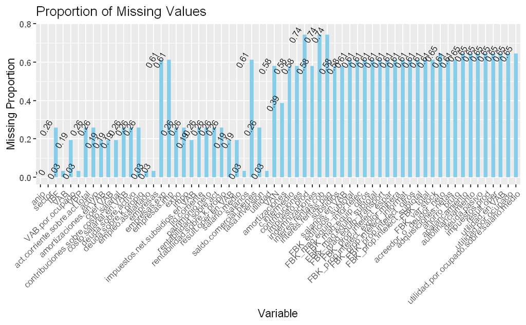

```r
# Assuming your data is in a variable named 'data'
data_missing %>%
  # Reshape data for ggplot2
  # pivot_longer(names = "variable", values_from = "value", values_def = last()) %>%
  # Create bar chart with ggplot2
  ggplot(aes(x = variable, y = value)) +
  geom_col(stat = "identity", fill = "skyblue", width = 0.5) +  # Adjust bar width
  # Add text labels with round(value, 2) for 2 decimal places
  geom_text(aes(label = round(value, 2), x = variable, y = value + 0.02),
            vjust = -0.5, hjust = 1, size = 3, angle = 60) +  # Rotate text further
  labs(title = "Proportion of Missing Values",
       x = "Variable",
       y = "Missing Proportion") +
  # Adjust x-axis labels for readability (optional)
  theme(axis.text.x = element_text(angle = 45, hjust = 1))
```

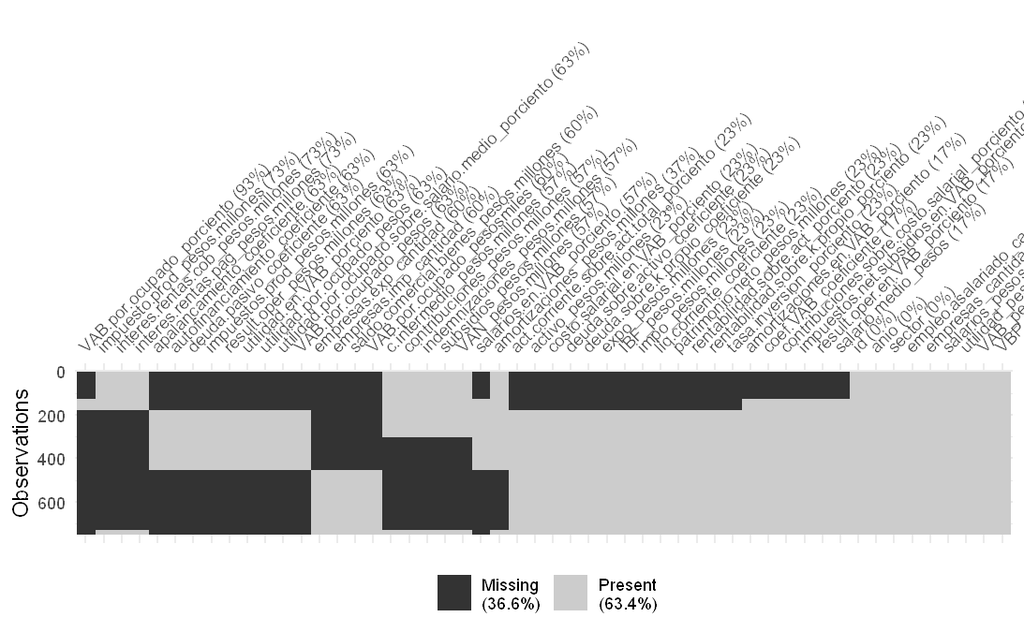

```r
library(visdat) # visualización de datos
library(naniar)

vis_miss(base.ENGE_1993a2022.wider,sort_miss = T,cluster = T,warn_large_data = T)
```

## Posibles cálculos

Posibles calculos

- VAB a precios basicos = VAB*(1+impuestos.net.subsidios.en.VAB/100)
- Amortizaciones = amortizaciones en vab*vab
- Productividad_corrientes = VAB a precios basicos / empleados
- IPI = indice de precios implícitos del VAB por rama, año a definir, buscar en indec
- Indice productividad (IPT) (en reales) = Productividad corrientes / IPI
- Masa salarial = (costo salarial en vab/100)*vab
- Consumo intermedio = VBP-VAB
- Ganancia antes de impuestos = VAB a precios basicos - Amortizaciones - masa salarial
- Impuestos a las ganancias = buscar
- Ganancia despues de impuestos = VAB a precios basicos - Amortizaciones - costo salarial - impuestos a las ganancias
- Activo corriente = act.corriente_sobre_act.total*activo
- activo no corriente = activo-activo corriente
- Stock de capital = (amortizaciones_en_vab*vab)*depreciación anual
- Indice consumo capital fijo= amortizaciones/activo no corriente
- Rotación de capital aproximada = (amortizaciones + masa salarial + consumo intermedio)/activo corriente
- Capital variable adelantado = masa salarial / rotación
- Capital constante circulante adelantado = consumo intermedio / rotación Tasa de ganancia = Ganancia / (stock de capital + capital variable adelantado + capital constante circulante adelantado)

```r
names(df_pivot)
```

```
 [1] "anio"                                     "sector"
 [3] "IBF"                                      "VAB"
 [5] "VAB.por.ocupado"                          "VBP"
 [7] "act.corriente.sobre.act.total"            "activo"
 [9] "amortizaciones.en.VAB"                    "coef.VAB"
[11] "contribuciones.sobre.costo.salarial"      "costo.salarial.en.VAB"
[13] "deuda.sobre.activo"                       "deuda.sobre.k.propio"
[15] "empleo.asalariado"                        "empresas"
[17] "empresas.exp"                             "empresas.imp"
[19] "expo"                                     "impo"
[21] "impuestos.net.subsidios.en.VAB"           "liq.corriente"
[23] "patrimonio.neto"                          "rentabilidad.sobre.act"
[25] "rentabilidad.sobre.k.propio"              "result.oper.en.VAB"
[27] "salario.medio"                            "salarios"
[29] "saldo.comercial.bienes"                   "tasa.inversion"
```

[output cut: 17 more lines]

```r
# summary(df_pivot$amortizaciones)
```

```r
df_indicadores <-  df_pivot %>%
  mutate(VAB.precios.basicos = VAB *((1 +impuestos.net.subsidios.en.VAB)/100),
         amortizaciones = amortizaciones.en.VAB*VAB,

         productividad_corrientes = VAB.precios.basicos / empleo.asalariado,
        # - IPI = indice de precios implícitos del VAB por rama, año a definir, buscar en indec
        # - Indice productividad (IPT) (en reales) = Productividad corrientes / IPI
        masa_salarial = (costo.salarial.en.VAB/100)*VAB.precios.basicos,
        consumo_intermedio = VBP-VAB.precios.basicos,
        ganancia_antes_de_impuestos = VAB.precios.basicos - amortizaciones - masa_salarial,
        # - Impuestos a las ganancias = buscar
        ganancia_despues_impuestos = VAB.precios.basicos - amortizaciones - masa_salarial,# - impuestos a las ganancias
        activo_corriente = act.corriente.sobre.act.total*activo,
        activo_no_corriente = activo-activo_corriente,
        stock_de_capital = (amortizaciones.en.VAB*VAB)*0.06, #¿De dónde salió este 0.06?
        indice_consumo_capital_fijo= amortizaciones/activo_no_corriente,
        rotacion_capital_aproximada = (amortizaciones + masa_salarial + consumo_intermedio)/activo_corriente,
        capital_variable_adelantado = masa_salarial / rotacion_capital_aproximada,
        capital_constante_circulante_adelantado = consumo_intermedio / rotacion_capital_aproximada,
        tasa_de_ganancia = result.oper / (capital_variable_adelantado + capital_constante_circulante_adelantado + stock_de_capital)

        )
df_indicadores
```

| anio | sector | IBF | VAB | VAB.por.ocupado | VBP | act.corriente.sobre.act.total | activo | amortizaciones.en.VAB | coef.VAB | contribuciones.sobre.costo.salarial | costo.salarial.en.VAB | deuda.sobre.activo | deuda.sobre.k.propio | empleo.asalariado | empresas | empresas.exp | empresas.imp | expo | impo | impuestos.net.subsidios.en.VAB | liq.corriente | patrimonio.neto | rentabilidad.sobre.act | rentabilidad.sobre.k.propio | result.oper.en.VAB | salario.medio | salarios | saldo.comercial.bienes | tasa.inversion | … |
| --- | --- | --- | --- | --- | --- | --- | --- | --- | --- | --- | --- | --- | --- | --- | --- | --- | --- | --- | --- | --- | --- | --- | --- | --- | --- | --- | --- | --- | --- | --- |
| 1993 | k.ext.part.50.percent | 3934000000 | 8486400000 | 78700.0 | 19472600000 | 0.00000 | 0 | 19.800000 | 43.60000 | 24.30000 | 34.70000 | 0.00000 | 0.00000 | 107774 | 58 | 32 | 47 | 1848400000 | 1480400000 | 16.2000000 | 0.00000 | 0 | 0.0000000 | 0.0000000 | 29.400000 | 1590.00 | 2227700000 | 368000000 | 46.9000000 | … |
| 1993 | k.ext.part.50a98.9.percent | 2086800000 | 4897000000 | 78700.0 | 11571700000 | 0.00000 | 0 | 9.200000 | 42.30000 | 26.30000 | 33.00000 | 0.00000 | 0.00000 | 62262 | 65 | 36 | 50 | 875400000 | 1304900000 | 37.0000000 | 0.00000 | 0 | 0.0000000 | 0.0000000 | 20.700000 | 1474.00 | 1192900000 | -429500000 | 45.5000000 | … |
| 1993 | k.ext.part.99a100.percent | 810100000 | 5420400000 | 73900.0 | 13557800000 | 0.00000 | 0 | 7.800000 | 40.00000 | 25.20000 | 42.00000 | 0.00000 | 0.00000 | 73344 | 96 | 80 | 89 | 2201300000 | 2644900000 | 23.8000000 | 0.00000 | 0 | 0.0000000 | 0.0000000 | 26.400000 | 1784.00 | 1701500000 | -443700000 | 16.2000000 | … |
| 1993 | k.ext.subtotal | 6830900000 | 18803800000 | 77300.0 | 44602200000 | 0.00000 | 0 | 13.600000 | 42.20000 | 25.10000 | 36.40000 | 0.00000 | 0.00000 | 243380 | 219 | 148 | 186 | 4925100000 | 5430200000 | 23.8000000 | 0.00000 | 0 | 0.0000000 | 0.0000000 | 26.300000 | 1619.00 | 5122100000 | -505200000 | 37.7000000 | … |
| 1993 | k.nac | 2337000000 | 11719100000 | 31900.0 | 29734900000 | 0.00000 | 0 | 11.700000 | 39.40000 | 23.90000 | 62.00000 | 0.00000 | 0.00000 | 366878 | 281 | 144 | 185 | 2457300000 | 1719500000 | -0.7000000 | 0.00000 | 0 | 0.0000000 | 0.0000000 | 27.000000 | 1160.00 | 5533300000 | 737800000 | 20.3000000 | … |
| 1993 | k.no.privat | 3312100000 | 21199800000 | 40600.0 | 55821400000 | 0.00000 | 0 | 9.800000 | 38.00000 | 24.40000 | 54.20000 | 0.00000 | 0.00000 | 521944 | 450 | 277 | 340 | 6349100000 | 6477600000 | 13.4000000 | 0.00000 | 0 | 0.0000000 | 0.0000000 | 22.500000 | 1279.00 | 8681000000 | -128500000 | 16.5000000 | … |
| 1993 | k.privat.conce | 5855800000 | 9323100000 | 105600.0 | 18515700000 | 0.00000 | 0 | 19.700000 | 50.40000 | 24.50000 | 28.10000 | 0.00000 | 0.00000 | 88314 | 50 | 15 | 31 | 1033300000 | 672100000 | 16.5000000 | 0.00000 | 0 | 0.0000000 | 0.0000000 | 35.800000 | 1720.00 | 1974400000 | 361100000 | 63.9000000 | … |
| 1993 | manufactura.alimentos | 738800000 | 5636400000 | 50800.0 | 16393300000 | 0.00000 | 0 | 6.000000 | 34.40000 | 25.30000 | 38.00000 | 0.00000 | 0.00000 | 110921 | 109 | 85 | 83 | 3542000000 | 719800000 | 33.1000000 | 0.00000 | 0 | 0.0000000 | 0.0000000 | 22.900000 | 1110.00 | 1600200000 | 2822200000 | 15.4000000 | … |
| 1993 | manufactura.combustibles | 813600000 | 5624100000 | 102900.0 | 13998300000 | 0.00000 | 0 | 8.300000 | 40.20000 | 25.70000 | 33.40000 | 0.00000 | 0.00000 | 54652 | 91 | 82 | 87 | 1077400000 | 1556000000 | 42.1000000 | 0.00000 | 0 | 0.0000000 | 0.0000000 | 16.300000 | 1961.00 | 1393600000 | -478600000 | 16.0000000 | … |
| 1993 | manufactura.maquinaria | 204200000 | 2289000000 | 48400.0 | 8532600000 | 0.00000 | 0 | 9.500000 | 26.80000 | 26.00000 | 61.00000 | 0.00000 | 0.00000 | 47257 | 44 | 34 | 40 | 1018400000 | 2514500000 | -2.6000000 | 0.00000 | 0 | 0.0000000 | 0.0000000 | 32.100000 | 1682.00 | 1033200000 | -1496100000 | 11.7000000 | … |

[output cut: 765 more lines]

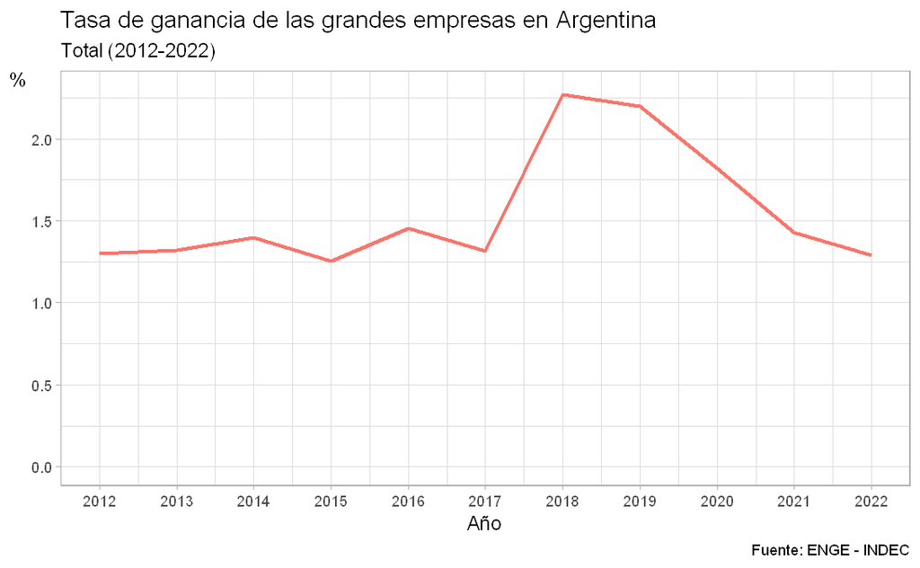

```r
#Gráfico de tasa de ganancia

df_indicadores %>%
  filter(!is.na(tasa_de_ganancia) & is.finite(tasa_de_ganancia) & sector == "total") %>%
  select(anio, tasa_de_ganancia) %>%
  mutate(tasa_de_ganancia = tasa_de_ganancia*100)%>%
  ggplot()+
  geom_line(size=1) +
  theme_light() +
  aes(x = anio, y = tasa_de_ganancia, color = "red") +
  labs(title = "Tasa de ganancia de las grandes empresas en Argentina",
       subtitle = "Total (2012-2022)",
       y = "%",
       x = "Año",
       caption = "Fuente: ENGE - INDEC") +
  scale_x_continuous(n.breaks = 10) +
  scale_y_continuous(n.breaks = 5, limits = c(0,2.3)) +
  theme(legend.position = "none",
        axis.title.y = element_text(angle = 0))

  ggsave(filename = "./Output/tasa.ganancia.total_2012_2022.png",
       dpi = "retina",
       device = "png",
       width = 10,
       height = 7 )
```

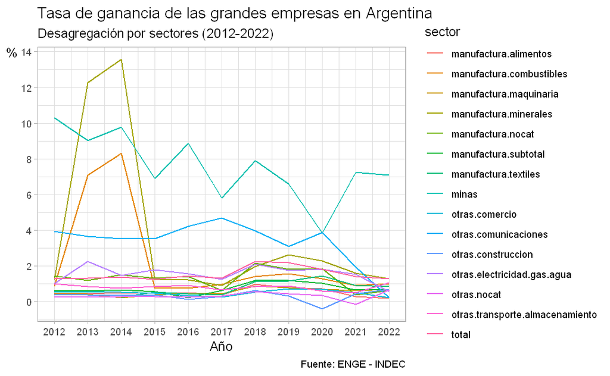

```r
#Gráfico de tasa de ganancia

df_indicadores %>%
  filter(!is.na(tasa_de_ganancia) & is.finite(tasa_de_ganancia)) %>%
  select(anio, sector, tasa_de_ganancia) %>%
  mutate(tasa_de_ganancia = tasa_de_ganancia*100)%>%
  ggplot()+
  geom_line() +
  theme_light() +
  aes(x = anio, y = tasa_de_ganancia, color = sector) +
  labs(title = "Tasa de ganancia de las grandes empresas en Argentina",
       subtitle = "Desagregación por sectores (2012-2022)",
       y = "%",
       x = "Año",
       caption = "Fuente: ENGE - INDEC") +
  scale_x_continuous(n.breaks = 10) +
  scale_y_continuous(n.breaks = 10)  +
  theme(axis.title.y = element_text(angle = 0))

  ggsave(filename = "./Output/tasa.ganancia.sectores_2012_2022.png",
       dpi = "retina",
       device = "png",
       width = 10,
       height = 7 )
```

```r
# Write the data frame to a CSV file
write.csv(df_indicadores, file = 'Output/enge_indicadores.csv', row.names = FALSE)

# .xlsx file (View JK)
write.xlsx(df_pivot, file = "Output/df_enge_1993_2022_pivot.xlsx")
write.xlsx(df_indicadores, file = "Output/enge_indicadores.xlsx")
```

```r
# summary(df_indicadores)
unique(df_indicadores$sector)
```

```
 [1] "k.ext.part.50.percent"           "k.ext.part.50a98.9.percent"
 [3] "k.ext.part.99a100.percent"       "k.ext.subtotal"
 [5] "k.nac"                           "k.no.privat"
 [7] "k.privat.conce"                  "manufactura.alimentos"
 [9] "manufactura.combustibles"        "manufactura.maquinaria"
[11] "manufactura.minerales"           "manufactura.nocat"
[13] "manufactura.resto"               "manufactura.subtotal"
[15] "manufactura.textiles"            "minas"
[17] "otras.comercio"                  "otras.comunicaciones"
[19] "otras.construccion"              "otras.electricidad.gas.agua"
[21] "otras.nocat"                     "otras.resto"
[23] "otras.subtotal"                  "otras.transporte.almacenamiento"
[25] "total"
```

```r
df_indicadores.1 <-  df_pivot %>%
  mutate(VAB.precios.basicos = VAB *((1 +impuestos.net.subsidios.en.VAB)/100),
         amortizaciones = amortizaciones.en.VAB*VAB,

         productividad_corrientes = VAB.precios.basicos / empleo.asalariado,
        # - IPI = indice de precios implícitos del VAB por rama, año a definir, buscar en indec
        # - Indice productividad (IPT) (en reales) = Productividad corrientes / IPI
        masa_salarial = (costo.salarial.en.VAB/100)*VAB.precios.basicos,
        consumo_intermedio = VBP-VAB.precios.basicos,
        ganancia_antes_de_impuestos = VAB.precios.basicos - amortizaciones - masa_salarial,
        # - Impuestos a las ganancias = buscar
        ganancia_despues_impuestos = VAB.precios.basicos - amortizaciones - masa_salarial,# - impuestos a las ganancias
        activo_corriente = act.corriente.sobre.act.total*activo,
        activo_no_corriente = activo-activo_corriente,
        stock_de_capital = (amortizaciones.en.VAB*VAB)*0.06,
        indice_consumo_capital_fijo= amortizaciones/activo_no_corriente,
        rotacion_capital_aproximada = (amortizaciones + masa_salarial + consumo_intermedio)/activo_corriente,
        capital_variable_adelantado = masa_salarial / rotacion_capital_aproximada,
        capital_constante_circulante_adelantado = consumo_intermedio / rotacion_capital_aproximada,
        result.oper = result.oper.en.VAB*VAB/100,
        tasa_de_ganancia = result.oper / (capital_variable_adelantado + capital_constante_circulante_adelantado + stock_de_capital)

        )

df_indicadores.1
```

| anio | sector | IBF | VAB | VAB.por.ocupado | VBP | act.corriente.sobre.act.total | activo | amortizaciones.en.VAB | coef.VAB | contribuciones.sobre.costo.salarial | costo.salarial.en.VAB | deuda.sobre.activo | deuda.sobre.k.propio | empleo.asalariado | empresas | empresas.exp | empresas.imp | expo | impo | impuestos.net.subsidios.en.VAB | liq.corriente | patrimonio.neto | rentabilidad.sobre.act | rentabilidad.sobre.k.propio | result.oper.en.VAB | salario.medio | salarios | saldo.comercial.bienes | tasa.inversion | … |
| --- | --- | --- | --- | --- | --- | --- | --- | --- | --- | --- | --- | --- | --- | --- | --- | --- | --- | --- | --- | --- | --- | --- | --- | --- | --- | --- | --- | --- | --- | --- |
| 1993 | k.ext.part.50.percent | 3934000000 | 8486400000 | 78700.0 | 19472600000 | 0.00000 | 0 | 19.800000 | 43.60000 | 24.30000 | 34.70000 | 0.00000 | 0.00000 | 107774 | 58 | 32 | 47 | 1848400000 | 1480400000 | 16.2000000 | 0.00000 | 0 | 0.0000000 | 0.0000000 | 29.400000 | 1590.00 | 2227700000 | 368000000 | 46.9000000 | … |
| 1993 | k.ext.part.50a98.9.percent | 2086800000 | 4897000000 | 78700.0 | 11571700000 | 0.00000 | 0 | 9.200000 | 42.30000 | 26.30000 | 33.00000 | 0.00000 | 0.00000 | 62262 | 65 | 36 | 50 | 875400000 | 1304900000 | 37.0000000 | 0.00000 | 0 | 0.0000000 | 0.0000000 | 20.700000 | 1474.00 | 1192900000 | -429500000 | 45.5000000 | … |
| 1993 | k.ext.part.99a100.percent | 810100000 | 5420400000 | 73900.0 | 13557800000 | 0.00000 | 0 | 7.800000 | 40.00000 | 25.20000 | 42.00000 | 0.00000 | 0.00000 | 73344 | 96 | 80 | 89 | 2201300000 | 2644900000 | 23.8000000 | 0.00000 | 0 | 0.0000000 | 0.0000000 | 26.400000 | 1784.00 | 1701500000 | -443700000 | 16.2000000 | … |
| 1993 | k.ext.subtotal | 6830900000 | 18803800000 | 77300.0 | 44602200000 | 0.00000 | 0 | 13.600000 | 42.20000 | 25.10000 | 36.40000 | 0.00000 | 0.00000 | 243380 | 219 | 148 | 186 | 4925100000 | 5430200000 | 23.8000000 | 0.00000 | 0 | 0.0000000 | 0.0000000 | 26.300000 | 1619.00 | 5122100000 | -505200000 | 37.7000000 | … |
| 1993 | k.nac | 2337000000 | 11719100000 | 31900.0 | 29734900000 | 0.00000 | 0 | 11.700000 | 39.40000 | 23.90000 | 62.00000 | 0.00000 | 0.00000 | 366878 | 281 | 144 | 185 | 2457300000 | 1719500000 | -0.7000000 | 0.00000 | 0 | 0.0000000 | 0.0000000 | 27.000000 | 1160.00 | 5533300000 | 737800000 | 20.3000000 | … |
| 1993 | k.no.privat | 3312100000 | 21199800000 | 40600.0 | 55821400000 | 0.00000 | 0 | 9.800000 | 38.00000 | 24.40000 | 54.20000 | 0.00000 | 0.00000 | 521944 | 450 | 277 | 340 | 6349100000 | 6477600000 | 13.4000000 | 0.00000 | 0 | 0.0000000 | 0.0000000 | 22.500000 | 1279.00 | 8681000000 | -128500000 | 16.5000000 | … |
| 1993 | k.privat.conce | 5855800000 | 9323100000 | 105600.0 | 18515700000 | 0.00000 | 0 | 19.700000 | 50.40000 | 24.50000 | 28.10000 | 0.00000 | 0.00000 | 88314 | 50 | 15 | 31 | 1033300000 | 672100000 | 16.5000000 | 0.00000 | 0 | 0.0000000 | 0.0000000 | 35.800000 | 1720.00 | 1974400000 | 361100000 | 63.9000000 | … |
| 1993 | manufactura.alimentos | 738800000 | 5636400000 | 50800.0 | 16393300000 | 0.00000 | 0 | 6.000000 | 34.40000 | 25.30000 | 38.00000 | 0.00000 | 0.00000 | 110921 | 109 | 85 | 83 | 3542000000 | 719800000 | 33.1000000 | 0.00000 | 0 | 0.0000000 | 0.0000000 | 22.900000 | 1110.00 | 1600200000 | 2822200000 | 15.4000000 | … |
| 1993 | manufactura.combustibles | 813600000 | 5624100000 | 102900.0 | 13998300000 | 0.00000 | 0 | 8.300000 | 40.20000 | 25.70000 | 33.40000 | 0.00000 | 0.00000 | 54652 | 91 | 82 | 87 | 1077400000 | 1556000000 | 42.1000000 | 0.00000 | 0 | 0.0000000 | 0.0000000 | 16.300000 | 1961.00 | 1393600000 | -478600000 | 16.0000000 | … |
| 1993 | manufactura.maquinaria | 204200000 | 2289000000 | 48400.0 | 8532600000 | 0.00000 | 0 | 9.500000 | 26.80000 | 26.00000 | 61.00000 | 0.00000 | 0.00000 | 47257 | 44 | 34 | 40 | 1018400000 | 2514500000 | -2.6000000 | 0.00000 | 0 | 0.0000000 | 0.0000000 | 32.100000 | 1682.00 | 1033200000 | -1496100000 | 11.7000000 | … |

[output cut: 765 more lines]

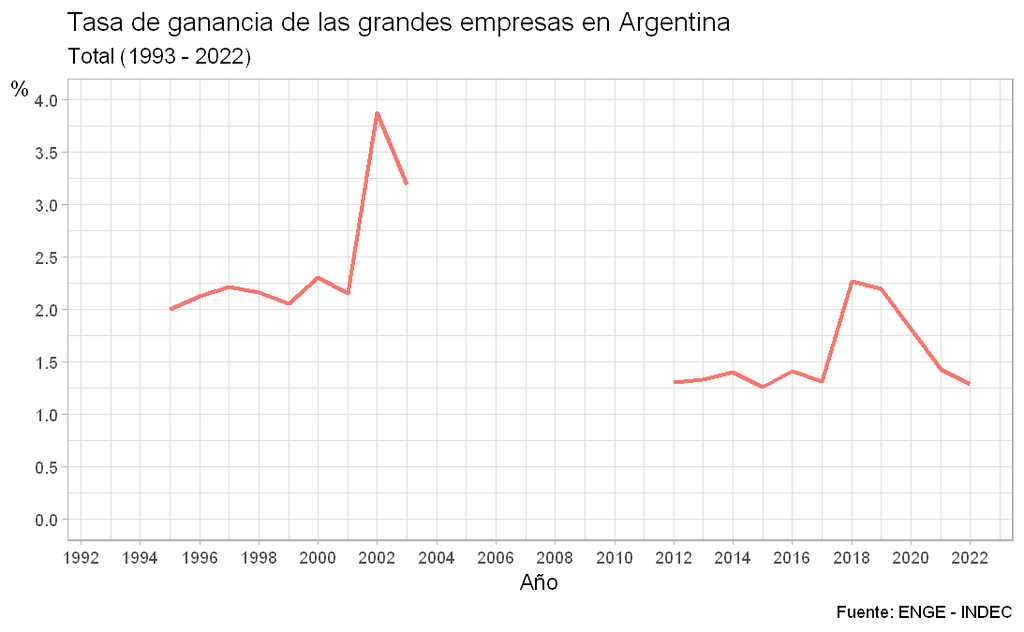

```r
#Revisar proque puede ser que haya un error en los cálculos para los años 1993, 1994 y 2004. Puede ser que la tasa de ganancia haya aumentado para esos años, pero los valores son demasiado altos.
#Encontré el problema: no están los datos de activos para esos años.
# Solución: ¿?

df_indicadores.1 %>%
  filter(!is.na(tasa_de_ganancia) &
           is.finite(tasa_de_ganancia) &
           sector == "total") %>%
  select(anio, tasa_de_ganancia) %>%
  mutate(tasa_de_ganancia = tasa_de_ganancia*100) %>%
  ggplot()+
  geom_line(size=1) +
  theme_light() +
  aes(x = anio, y = tasa_de_ganancia, color = "red") +
  labs(title = "Tasa de ganancia de las grandes empresas en Argentina",
       subtitle = "Total (1993 - 2022)",
       y = "%",
       x = "Año",
       caption = "Fuente: ENGE - INDEC") +
  scale_x_continuous(n.breaks = 20) +
  scale_y_continuous(n.breaks = 10, limits = c(0,4)) +
  theme(legend.position = "none",
        axis.title.y = element_text(angle = 0))


  ggsave(filename = "./Output/tasa.ganancia.total_1993_2022.png",
       dpi = "retina",
       device = "png",
       width = 10,
       height = 7 )
```

```r
#Hago algunos cálculo de prueba con lo que ya tengo
#base.ENGE_1993a2022.wider <- base.ENGE_1993a2022.wider %>%
 # mutate(VAB.precios.basicos = VAB_pesos.millones*((1 +impuestos.net.subsidios.en.VAB_porciento)/100))

#class(base.ENGE_1993a2022.wider$amortizaciones.en.VAB_porciento)
```

# Glosario

Por último se presenta el glosario completo de de indicadores, sectores y origen del capital:

```r
#Levanto la tabla con el glosario completo de indicadores, sectores y origen del capital
glosario <- openxlsx::read.xlsx(
  xlsxFile = "Fuentes/0.resumen_macro_eco-finan_enge_1993-2022_Yacovone.v2.2.1.xlsx",
  sheet = 6) %>%  #reexpreso a la luz de la homogeneización de mateo
  mutate(Unidad = case_when(Unidad.medida == "$" ~ "pesos",
                            Unidad.medida == "$miles" ~ "pesos",
                            Unidad.medida == "$millones" ~ "pesos",
                            Unidad.medida == "cantidad" ~ "cantidad",
                            Unidad.medida == "porciento" ~ "porciento")) %>%
  select(1,2,5,4)

#elaboro cuadro prolijo
write.xlsx(glosario, file = "Output/glosario.xlsx")

glosario %>% kbl(caption = "Cuadro 2. Glosario completo de variables, sectores y origen del capital") %>% kable_paper("hover", full_width = F)
```

Cuadro 2. Glosario completo de variables, sectores y origen del capital

| indic.sector.origen | Descripción | Unidad | Observaciones |
| --- | --- | --- | --- |
| anio | Año de observación | NA | NA |
| VBP | Valor Bruto de la Producción | pesos | NA |
| VAB | Valor Agregado Bruto | pesos | NA |
| utilidad | Utilidad | pesos | NA |
| IBF | Inversión Bruta Fija | pesos | NA |
| empleo.asalariado | Puestos de trabajo asalariado | cantidad | NA |
| salarios | Masa de salarios | pesos | NA |
| activo | Activo | pesos | NA |
| patrimonio.neto | Patrimonio neto | pesos | NA |
| empresas.exp | Empresas que exportan | cantidad | NA |
| exp | Exportación de bienes | pesos | NA |
| empresas.imp | Empresas que importan | cantidad | NA |
| imp | Importación de bienes | pesos | NA |
| saldo.comercial.bienes | Saldo comercial de bienes | pesos | NA |
| empresas | Cantidad de empresas | cantidad | NA |
| minas | Minas y canteras | NA | NA |
| manufactura.subtotal | Sub-total de industria manufacturera | NA | NA |
| manufactura.alimentos | Alimentos, bebidas y tabaco de la industria manufacturera | NA | NA |
| manufactura.combustibles | Combustibles, químicos y plásticos de la industria manufacturera | NA | NA |
| manufactura.maquinaria | Maquinarias, equipos y vehículos de la industria manufacturera | NA | NA |
| manufactura.resto | Resto de la industria manufacturera | NA | NA |
| manufactura.textiles | Textiles y cueros de la industria manufacturera. Desagredado del resto de la industria manufacturera (manufactura.resto) en publicaciones a partir de 2012. | NA | NA |
| manufactura.minerales | Minerales no metálicos, metales y productos de metal de la industria manufacturera. Desagredado del resto de la industria manufacturera (manufactura.resto) en publicaciones a partir de 2012. | NA | NA |
| manufactura.nocat | Otras actividades de la industria manufacturera no categorizadas. Desagredado del resto de la industria manufacturera (manufactura.resto) en publicaciones a partir de 2012. | NA | NA |
| otras.subtotal | Sub-total de otras actividades no manufactureras | NA | NA |
| otras.electricidad.gas.agua | Electricidad, gas y agua como otras actividades | NA | NA |
| otras.comunicaciones | Comunicaciones como otras actividades | NA | NA |
| otras.resto | Resto de actividades en las que se incluye Construcción, Comercio, Transporte y Otros servicios. | NA | NA |
| otras.construcción | Construcción. Desagregado del resto de otras actividades no manufactureras (otras.resto) en publicaciones a partir de 2012. | NA | NA |
| otras.comercio | Comercio. Desagregado del resto de actividades (otras.resto) en publicaciones a partir de 2012. | NA | NA |
| otras.transporte.almacenamiento | Transporte, correo y almacenamiento. Desagregado del resto de otras actividades no manufactureras (otras.resto) en publicaciones a partir de 2012. | NA | NA |
| otras.nocat | Otras actividades no categorizadas. Desagregado del resto de otras actividades no manufactureras (otras.resto) en publicaciones a partir de 2012. | NA | NA |
| k.nac | Capital de origen nacional. Incluye hasta un 10% de participación de capital de origen extranjero, que es inversión de cartera y que no se discrimina del total. | NA | NA |
| k.ext.subtotal | Sub-total de capital con participación de origen extranjero | NA | NA |
| k.ext.part.50.percent | Capital con hasta 50% de partición de origen extranjero | NA | NA |
| k.ext.part.50a98.9.percent | Capital con más 50% hasta 98, 9% de partición de origen extranjero | NA | NA |
| k.ext.part.99a100.percent | Capital con entre 99% y 100% de partición de origen extranjero | NA | NA |
| k.privat.conce | Capital en condición de privatizado y/o concesionado | NA | NA |
| k.no.privat | Capital en condición de no privatizado | NA | NA |
| c.intermedio | Consumo intermedio | pesos | NA |
| interes.rentas.cob | Intereses y rentas cobradas | pesos | NA |
| interes.rentas.pag | Intereses y rentas pagadas | pesos | NA |
| liq.corriente | Liquidez corriente= Activo Corriente / Pasivo Corriente | porciento | NA |
| deuda.sobre.activo | Endeudamiento= Pasivo Total / Activo Total | porciento | NA |
| deuda.sobre.k.propio | Relación Deuda con Capital propio = Pasivo Total / Patrimonio Neto | porciento | NA |
| act.corriente.sobre.act.total | Relación Activo corriente con Activo total = Activo Corriente / Activo Total | porciento | NA |
| deuda.pasivo | Endeudamiento del pasivo = Pasivo corriente/pasivo total | porciento | NA |
| apalancamiento | Apalancamiento = Activo total/patrimonio neto | porciento | NA |
| autofinanciamiento | Autofinanciación = Ahorro neto/formación bruta de capital fijo | porciento | NA |
| rentabilidad.sobre.act | Rentabilidad sobre activo = Utilidad(¹) / Activo Total | porciento | (¹) La utilidad se obtiene descontando del valor agregado a precios de productor las amortizaciones, los impuestos sobre la producción netos de subsidios, los salarios y las contribuciones sociales, l… |
| rentabilidad.sobre.k.propio | Rentabilidad sobre capital propio = Utilidad(¹) / Patrimonio Neto | porciento | NA |
| salarios.en.VAB | Participación de la remuneración en el VAB = Salarios/VAB | porciento | NA |
| costo.salarial.en.VAB | Participación del costo salarial en el valor agregado = (Salarios + Contribuciones sociales) / Valor agregado | porciento | NA |
| amortizaciones.en.VAB | Participación de las amortizaciones en el valor agregado = Amortizaciones / Valor agregado | porciento | NA |
| impuestos.net.subsidios.en.VAB | Participación de los impuestos netos de subsidios en el valor agregado = Impuesto neto de subsidios(²) / Valor agregado | porciento | (²) Impuestos sobre la producción, excluido el IVA |
| result.oper.en.VAB | Participación del resultado operativo (o excendente neto de explotación) en el valor agregado = Resultado operativo(³) / Valor agregado | porciento | (³) Resulta de deducir del valor agregado bruto las amortizaciones, los salarios, contribuciones y los impuestos sobre la producción netos de subsidios |
| utilidad.en.VAB | Participación de la utilidad en el VAB = Utilidad/VAB | porciento | NA |
| coef.VAB | Coeficiente de valor agregado = Valor agregado / Valor de producción | porciento | NA |
| salario.medio | Salario medio mensual = (Salarios / Asalariados ) / 13 meses | pesos | NA |
| contribuciones.sobre.costo.salarial | Participación de las contribuciones en el costo salarial = Contribuciones sociales / (Salarios + Contribuciones sociales) | porciento | NA |
| utilidad.por.ocupado | Utilidad media por asalariado = Utilidad/asalariados | pesos | NA |
| utilidad.por.ocupado.sobre.salario.medio | Utilidad por asalariado en porcentaje del salario medio = (Utilidad/asalariados)/salario medio | porciento | NA |
| VAB.por.ocupado | Valor agregado por ocupado = Valor agregado / Puestos de trabajo asalariado | pesos | NA |
| tasa.inversion | Tasa de inversión = Inversión bruta interna / Valor agregado | porciento | NA |
| ahorro_bruto | Ahorro bruto | NA | B8n |
| FBK_total | Formación bruta de capital por tipo de activo | NA | P5g |
| FBK_edificios_subtotal | Edificios y estructuras | NA | P51g AN112 |
| FBK_maq.equip_subtotal | Maquinaria y equipo | NA | P51g AN113 |
| FBK_maq.equip_transport | Equipo de transporte | NA | P51g AN1131 |
| FBK_maq.equip_infor.telec | Equipo para la informática y la telecomunicaciones | NA | P51g AN1132 |
| FBK_maq.equip_otros | Otras maquinarias y equipos | NA | P51g AN1139 |
| FBK_prop.intelect_subtotal | Productos de propiedad intelectual | NA | P51g AN117 |
| FBK_prop.intelect_explor.minera | Exploración y evaluación minera | NA | P51g AN1172 |
| FBK_prop.intelect_informat | Programas de informática y bases de datos | NA | P51g AN1173 |
| FBK_prop.intelect_espar | Originales para esparcimiento, literarios o artísticos | NA | P51g AN1174 |
| FBK_prop.intelect_otros | Otros productos de propiedad intelectual | NA | P52 AN12 |
| FBK_var.stock | Cambios en existencias | NA | P52 AN12 |
| adquisiciones.netas | Adquisiciones menos disposiciones de activos no producidos | NA | NP |
| acreedor_o_deudor_neto | Préstamo neto (+) / endeudamiento neto (–) | NA | B9 |